# Pemulusan

Nabil Naufal (G1401211008)

## Library yang digunakan

```r
library("forecast")
```

```r
library("graphics")
library("TTR")
library("TSA")
```

## Impor Data

```r
library(rio)
data <- import("https://raw.githubusercontent.com/mrnabilnaufal07/mpdw/main/Data/Data-Nabil.csv")
```

## Eksplorasi Data

Melihat data menggunakan fungsi `View()`, struktur data menggunakan fungsi `str()`, dan dimensi data menggunakan fungsi `dim()`.

```r
View(data)
str(data)
```

```
## 'data.frame':    172 obs. of  2 variables:
##  $ Periode  : int  1 2 3 4 5 6 7 8 9 10 ...
##  $ Meninggal: int  32 34 32 23 25 26 26 27 30 31 ...
```

```r
dim(data)
```

```
## [1] 172   2
```

Data terdiri dari dua peubah yaitu `Periode` dan `Meninggal` serta 172 baris. Kedua peubah bertipe integer. Data perlu diubah agar terbaca sebagai data deret waktu dengan fungsi `ts()`

```r
data.ts <- ts(data$Meninggal)
```

Menampilkan ringkasan data dengan fungsi `summary()`

```r
summary(data.ts)
```

```
##    Min. 1st Qu.  Median    Mean 3rd Qu.    Max.
##   16.00   27.00   32.00   32.98   38.00   55.00
```

Membuat plot data deret waktu

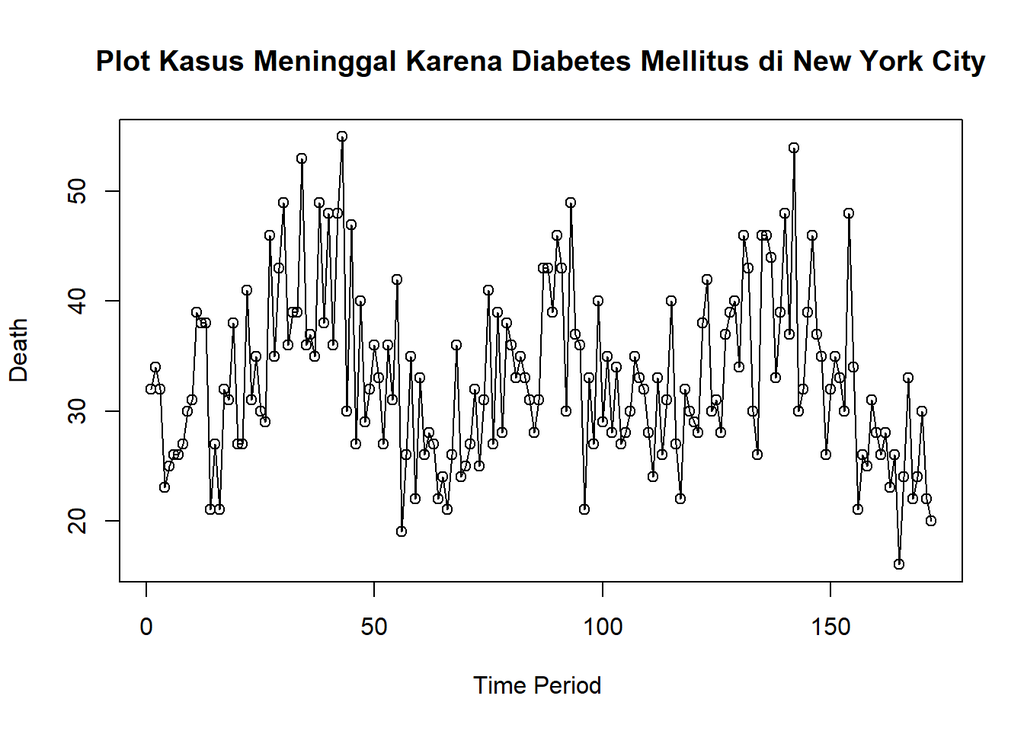

```r
ts.plot(data.ts, xlab="Time Period ", ylab="Death",
        main = "Plot Kasus Meninggal Karena Diabetes Mellitus di New York City")
points(data.ts)
```

Hasil plot menunjukkan pola musiman aditif. Oleh karena itu, metode pemulusan yang tepat digunakan untuk data tersebut adalah `Holt-Winter aditif`.

## Pemulusan Data Musiman

Membagi data menjadi data `training` dan data `testing` dengan proporsi 80% data `training` dan 20% data `uji`

```r
#membagi data menjadi training dan testing
training<-data[1:137,2] #data 1-137 merupakan 80% data pertama
testing<-data[138:172,2] #data 138-172 merupakan 20% data selanjutnya

#frecuency menunjukkan banyaknya periode waktu dalam satu musim. Untuk data ini, satu periode diperkirakan terdiri dari 61 periode (hasil eksplorasi)
training.ts<-ts(training, frequency = 61)
testing.ts<-ts(testing, frequency = 61)
```

Kemudian akan dilakukan eskplorasi dengan plot data deret waktu sebagai berikut.

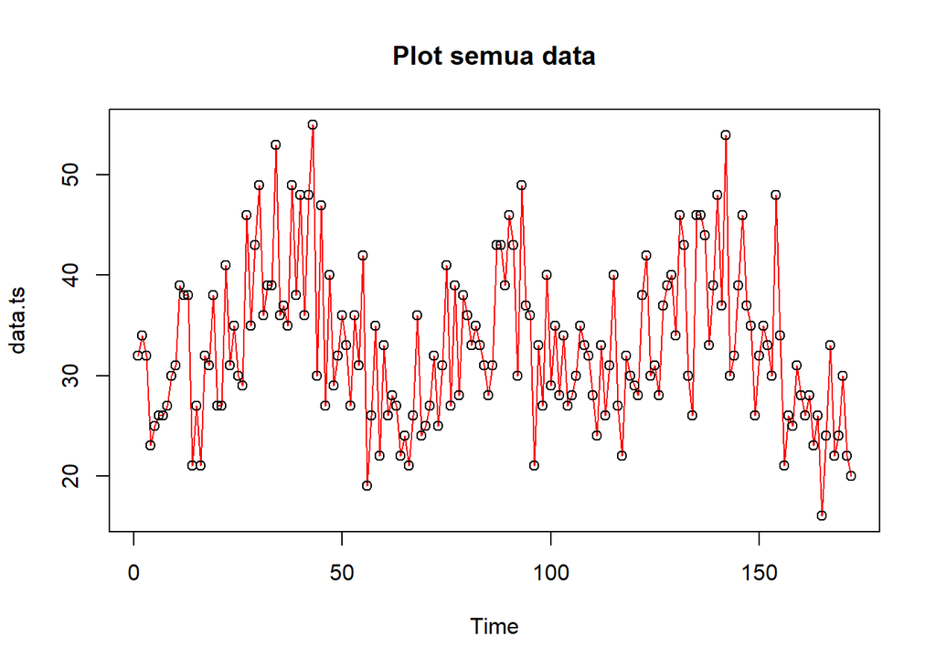

```r
#Membuat plot time series
plot(data.ts, col="red",main="Plot semua data")
points(data.ts)
```

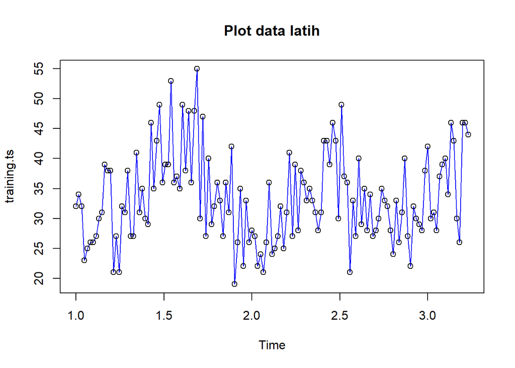

```r
plot(training.ts, col="blue",main="Plot data latih")
points(training.ts)
```

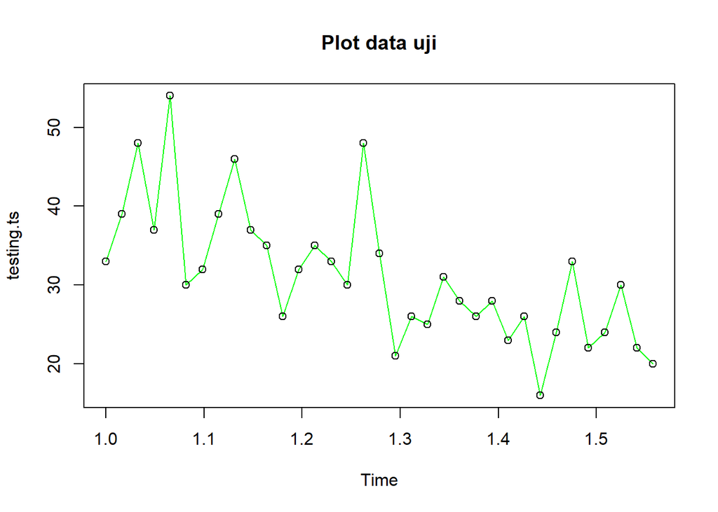

```r
plot(testing.ts, col="green",main="Plot data uji")
points(testing.ts)
```

Metode Holt-Winter untuk peramalan data musiman menggunakan tiga persamaan pemulusan yang terdiri atas persamaan untuk level $(L_t)$, trend $(B_t)$, dan komponen seasonal / musiman $(S_t)$ dengan parameter pemulusan berupa $\alpha$, $\beta$, dan $\gamma$. Metode Holt-Winter musiman terbagi menjadi dua, yaitu metode aditif dan metode multiplikatif.

Pemulusan data musiman dengan metode Holt-Winter dilakukan menggunakan fungsi `HoltWinters()` dengan memasukkan argumen tambahan, yaitu `gamma()` dan `seasonal()` . Arguman `seasonal()` diinisialisasi menyesuaikan jenis musiman, aditif atau multiplikatif.

### Winter Aditif

Perhitungan dengan model aditif dilakukan jika plot data asli menunjukkan fluktuasi musiman yang relatif stabil (konstan).

#### Pemulusan

```r
#Pemulusan dengan winter aditif dengan alpha=0.2, beta=0.1, dan gamma=0.1
winter1 <- HoltWinters(training.ts,alpha=0.2,beta=0.1,gamma=0.1,seasonal = "additive")
winter1$fitted
```

```
## Time Series:
## Start = c(2, 1)
## End = c(3, 15)
## Frequency = 61
##              xhat    level       trend       season
## 2.000000 27.62913 34.64682 -0.04778913  -6.96990056
## 2.016393 26.49900 34.67320 -0.04037168  -8.13383499
## 2.032787 21.60163 34.73303 -0.03035159 -13.10104811
## 2.049180 23.93761 34.78235 -0.02238423 -10.82235958
## 2.065574 21.17485 34.77245 -0.02113643 -13.57645794
## 2.081967 26.18082 34.71634 -0.02463349  -8.51088417
## 2.098361 36.24756 34.65554 -0.02824995   1.62026337
## 2.114754 24.31238 34.57778 -0.03320106 -10.23219565
## 2.131148 25.35800 34.48210 -0.03944875  -9.08465466
## 2.147541 27.45291 34.37105 -0.04660875  -6.87153991
## 2.163934 32.43781 34.23386 -0.05566687  -1.74039237
## 2.180328 25.51533 34.09064 -0.06442298  -8.51088417
## 2.196721 31.79655 33.92315 -0.07472957  -2.05186778
## 2.213115 41.57937 33.68911 -0.09066058   7.98091911
## 2.229508 27.63993 33.48257 -0.10224791  -5.74039237
## 2.245902 39.26575 33.25234 -0.11504659   6.12846009
## 2.262295 28.20699 33.08414 -0.12036165  -4.75678581
## 2.278689 37.99191 32.92238 -0.12450155   5.19403386
## 2.295082 35.93477 32.79950 -0.12433983   3.25960763
## 2.311475 33.02150 32.68820 -0.12303513   0.45632894
## 2.327869 34.89373 32.56087 -0.12346510   2.45632894
## 2.344262 32.81004 32.45866 -0.12133977   0.47272239
## 2.360656 30.81246 32.37531 -0.11754058  -1.44531040
## 2.377049 27.58864 32.29528 -0.11378976  -4.59285138
## 2.393443 30.81125 32.26376 -0.10556249  -1.34694974
## 2.409836 42.69803 32.19595 -0.10178746  10.60386993
## 2.426230 42.56432 32.15455 -0.09574807  10.50550927
## 2.442623 38.64639 32.14594 -0.08703439   6.58747648
## 2.459016 45.52239 32.12963 -0.07996211  13.47272239
## 2.475410 42.62947 32.14519 -0.07040995  10.55468960
## 2.491803 31.21435 32.14889 -0.06299937  -0.87153991
## 2.508197 35.72026 31.84302 -0.08728633   3.96452567
## 2.524590 38.66927 34.41168  0.17830851   4.07927976
## 2.540984 52.64427 34.25614  0.14492314  18.24321419
## 2.557377 32.11106 31.07220 -0.18796231   1.22682075
```

[output cut: 26 more lines]

```
## 3.000000 31.97981 38.19629  0.72374959  -6.94023076
## 3.016393 33.75448 40.92408  0.92415332  -8.09375466
## 3.032787 28.87722 41.09734  0.84906372 -13.06917866
## 3.049180 32.44511 42.37096  0.89151924 -10.81736837
## 3.065574 29.58563 42.37346  0.80261707 -13.59044619
## 3.081967 37.08450 44.65895  0.95090455  -8.52534999
## 3.098361 48.58262 45.99295  0.98921452   1.60045891
## 3.114754 35.82602 45.26564  0.81756202 -10.25718641
## 3.131148 37.38575 45.71800  0.78104169  -9.11329465
## 3.147541 42.26745 48.22189  0.95332676  -6.90777238
## 3.163934 48.51429 49.32173  0.96797783  -1.77541680
## 3.180328 38.63243 46.58685  0.59769202  -8.55211053
## 3.196721 42.88751 44.65806  0.34504341  -2.11559181
## 3.213115 53.96746 45.62560  0.40729328   7.93456977
## 3.229508 38.89576 44.43940  0.24794407  -5.79158708
```

```r
xhat1 <- winter1$fitted[,2]

#Pemulusan dengan winter aditif dengan parameter yang dioptimalkan
winter1.opt<- HoltWinters(training.ts, alpha= NULL,  beta = NULL, gamma = NULL, seasonal = "additive")
winter1.opt
```

```
## Holt-Winters exponential smoothing with trend and additive seasonal component.
##
## Call:
## HoltWinters(x = training.ts, alpha = NULL, beta = NULL, gamma = NULL,     seasonal = "additive")
##
## Smoothing parameters:
##  alpha: 0.2376982
##  beta : 0
##  gamma: 0
##
## Coefficients:
##             [,1]
## a    43.42119243
## b    -0.04778913
## s1    6.12846009
## s2   -4.75678581
## s3    5.19403386
## s4    3.25960763
## s5    0.45632894
## s6    2.45632894
## s7    0.47272239
## s8   -1.44531040
## s9   -4.59285138
## s10  -1.34694974
## s11  10.60386993
## s12  10.50550927
## s13   6.58747648
## s14  13.47272239
## s15  10.55468960
## s16  -0.87153991
## s17   3.96452567
## s18   4.07927976
## s19  18.24321419
## s20   1.22682075
## s21   2.29239452
## s22   0.29239452
## s23  14.12846009
## s24   3.17764042
## s25  13.25960763
## s26   1.32518140
```

[output cut: 20 more lines]

```
## s47  -6.96990056
## s48  -8.13383499
## s49 -13.10104811
## s50 -10.82235958
## s51 -13.57645794
## s52  -8.51088417
## s53   1.62026337
## s54 -10.23219565
## s55  -9.08465466
## s56  -6.87153991
## s57  -1.74039237
## s58  -8.51088417
## s59  -2.05186778
## s60   7.98091911
## s61  -5.74039237
```

```r
winter1.opt$fitted
```

```
## Time Series:
## Start = c(2, 1)
## End = c(3, 15)
## Frequency = 61
##              xhat    level       trend       season
## 2.000000 27.62913 34.64682 -0.04778913  -6.96990056
## 2.016393 26.50556 34.68718 -0.04778913  -8.13383499
## 2.032787 21.60808 34.75692 -0.04778913 -13.10104811
## 2.049180 23.93214 34.80229 -0.04778913 -10.82235958
## 2.065574 21.14638 34.77063 -0.04778913 -13.57645794
## 2.081967 26.12937 34.68805 -0.04778913  -8.51088417
## 2.098361 36.18198 34.60951 -0.04778913   1.62026337
## 2.114754 24.23848 34.51846 -0.04778913 -10.23219565
## 2.131148 25.28154 34.41399 -0.04778913  -9.08465466
## 2.147541 27.37995 34.29927 -0.04778913  -6.87153991
## 2.163934 32.37299 34.16117 -0.04778913  -1.74039237
## 2.180328 25.46605 34.02472 -0.04778913  -8.51088417
## 2.196721 31.76650 33.86616 -0.04778913  -2.05186778
## 2.213115 41.56930 33.63617 -0.04778913   7.98091911
## 2.229508 27.66488 33.45306 -0.04778913  -5.74039237
## 2.245902 39.32790 33.24723 -0.04778913   6.12846009
## 2.262295 28.31693 33.12150 -0.04778913  -4.75678581
## 2.278689 38.14462 32.99838 -0.04778913   5.19403386
## 2.295082 36.12803 32.91621 -0.04778913   3.25960763
## 2.311475 33.24653 32.83799 -0.04778913   0.45632894
## 2.327869 35.14014 32.73160 -0.04778913   2.45632894
## 2.344262 33.07543 32.65050 -0.04778913   0.47272239
## 2.360656 31.09168 32.58478 -0.04778913  -1.44531040
## 2.377049 27.87456 32.51520 -0.04778913  -4.59285138
## 2.393443 31.10249 32.49723 -0.04778913  -1.34694974
## 2.409836 42.98116 32.42508 -0.04778913  10.60386993
## 2.426230 42.83949 32.38177 -0.04778913  10.50550927
## 2.442623 38.91182 32.37213 -0.04778913   6.58747648
## 2.459016 45.77024 32.34530 -0.04778913  13.47272239
## 2.475410 42.85903 32.35213 -0.04778913  10.55468960
## 2.491803 31.41852 32.33785 -0.04778913  -0.87153991
## 2.508197 35.86962 31.95288 -0.04778913   3.96452567
## 2.524590 39.05765 35.02616 -0.04778913   4.07927976
## 2.540984 52.68469 34.48927 -0.04778913  18.24321419
## 2.557377 31.65459 30.47556 -0.04778913   1.22682075
```

[output cut: 26 more lines]

```
## 3.000000 30.06477 37.08246 -0.04778913  -6.96990056
## 3.016393 31.69003 39.87166 -0.04778913  -8.13383499
## 3.032787 26.27331 39.42215 -0.04778913 -13.10104811
## 3.049180 29.62774 40.49789 -0.04778913 -10.82235958
## 3.065574 26.43894 40.06319 -0.04778913 -13.57645794
## 3.081967 33.96707 42.52574 -0.04778913  -8.51088417
## 3.098361 45.24675 43.67427 -0.04778913   1.62026337
## 3.114754 32.09936 42.37934 -0.04778913 -10.23219565
## 3.131148 33.65089 42.78333 -0.04778913  -9.08465466
## 3.147541 38.75157 45.67090 -0.04778913  -6.87153991
## 3.163934 44.84478 46.63296 -0.04778913  -1.74039237
## 3.180328 34.49792 43.05659 -0.04778913  -8.51088417
## 3.196721 38.88921 40.98886 -0.04778913  -2.05186778
## 3.213115 50.56443 42.63130 -0.04778913   7.98091911
## 3.229508 35.71037 41.49855 -0.04778913  -5.74039237
```

```r
xhat1.opt <- winter1.opt$fitted[,2]
```

#### Peramalan

```r
#Forecast data uji
forecast.testing1 <- predict(winter1, n.ahead = 35) #n.ahead=35 menunjukkan banyaknya data yang akan dilakukan peramalan, dalam hal ini 35

forecast.testing1.opt <- predict(winter1.opt, n.ahead = 35) #untuk parameter yang dioptimalkan
```

#### Plot Deret Waktu

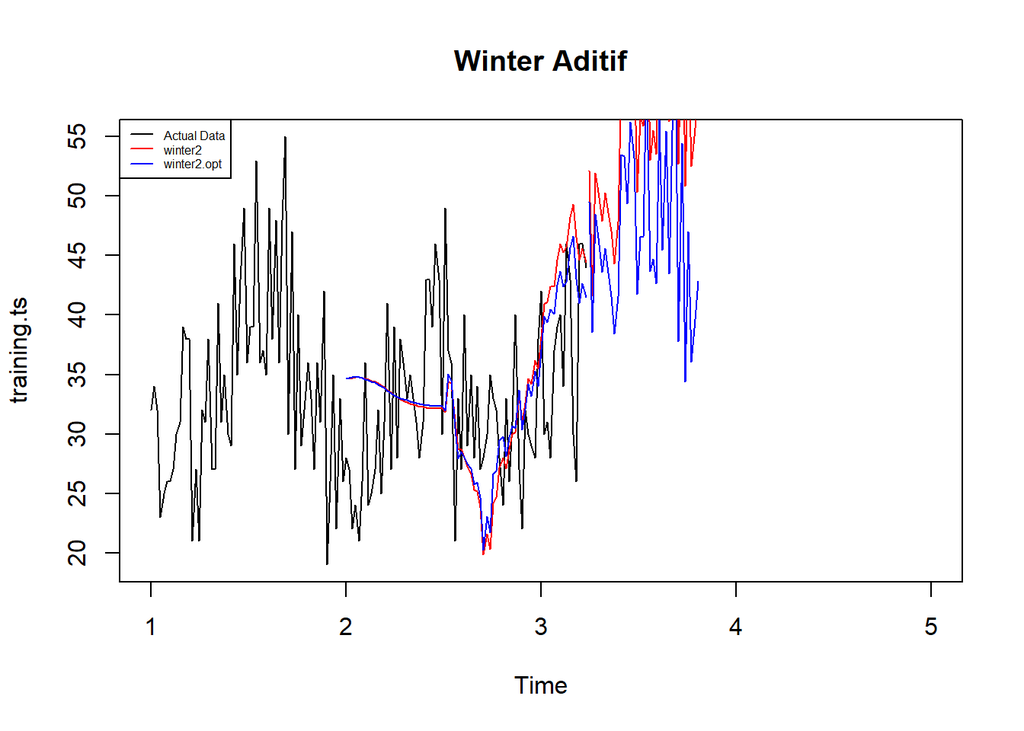

```r
#Plot time series
plot(training.ts,main="Winter Aditif",type="l",col="black",
     xlim=c(1,5),pch=1)
lines(xhat1,type="l",col="red")
lines(xhat1.opt,type="l",col="blue")
lines(forecast.testing1,type="l",col="red")
lines(forecast.testing1.opt,type="l",col="blue")
legend("topleft",c("Actual Data",expression(paste(winter2)),
                   expression(paste(winter2.opt))),cex=0.5,
       col=c("black","red","blue"),lty=1)
```

#### Akurasi Data Latih

```r
#Akurasi data training
SSE1<-winter1$SSE
MSE1<-winter1$SSE/length(training.ts)
RMSE1<-sqrt(MSE1)

akurasi1 <- matrix(c(SSE1,MSE1,RMSE1))
row.names(akurasi1)<- c("SSE", "MSE", "RMSE")
colnames(akurasi1) <- c("Akurasi")
akurasi1
```

```
##         Akurasi
## SSE  3647.76422
## MSE    26.62602
## RMSE    5.16004
```

```r
SSE1.opt<-winter1.opt$SSE
MSE1.opt<-winter1.opt$SSE/length(training.ts)
RMSE1.opt<-sqrt(MSE1.opt)
akurasi1.opt <- matrix(c(SSE1.opt,MSE1.opt,RMSE1.opt))
row.names(akurasi1.opt)<- c("SSE1.opt", "MSE1.opt", "RMSE1.opt")
colnames(akurasi1.opt) <- c("Akurasi")
akurasi1.opt
```

```
##               Akurasi
## SSE1.opt  3579.876405
## MSE1.opt    26.130485
## RMSE1.opt    5.111799
```

```r
akurasi1.train = data.frame(Model_Winter = c("Winter1","Winter1 optimal"),
                            Nilai_SSE=c(SSE1,SSE1.opt),
                            Nilai_MSE=c(MSE1,MSE1.opt),Nilai_RMSE=c(RMSE1,RMSE1.opt))
akurasi1.train
```

```
##      Model_Winter Nilai_SSE Nilai_MSE Nilai_RMSE
## 1         Winter1  3647.764  26.62602   5.160040
## 2 Winter1 optimal  3579.876  26.13048   5.111799
```

Akurasi pada model `Winter1 optimal` dengan data training lebih baik dibandingkan model `Winter1`. Ditandai dengan nilai SSE, MSE, dan RMSE yang lebih kecil. Selanjutnya,akan dilihat juga akurasi dari data uji kedua model tersebut dengan tambahan `Nilai MAPE` sebagai tolak ukur kelayakan model pada data uji.

#### Akurasi Data Uji

```r
#Akurasi Data Testing
forecast.testing1<-data.frame(forecast.testing1)
testing.ts<-data.frame(testing.ts)
selisih1<-forecast.testing1-testing.ts
SSEtesting1<-sum(selisih1^2)
MSEtesting1<-SSEtesting1/length(testing.ts)
RMSEtesting1<-sqrt(MSEtesting1)

# memuat paket MLmetrics
library(MLmetrics)
```

```r
# menghitung MAPE
MAPEtesting1 <- MAPE(as.numeric(unlist(forecast.testing1)), as.numeric(unlist(testing.ts)))

forecast.testing1.opt<-data.frame(forecast.testing1.opt)
selisih1.opt<-forecast.testing1.opt-testing.ts
SSEtesting1.opt<-sum(selisih1.opt^2)
MSEtesting1.opt<-SSEtesting1.opt/length(testing.ts)
RMSEtesting1.opt<-sqrt(MSEtesting1.opt)
MAPEtesting1.opt <- MAPE(as.numeric(unlist(forecast.testing1.opt)), as.numeric(unlist(testing.ts)))

akurasi1.test = data.frame(Model_Winter = c("Winter1","Winter1 optimal"),
                            Nilai_SSE=c(SSEtesting1,SSEtesting1.opt), Nilai_MSE=c(MSEtesting1,MSEtesting1.opt),Nilai_RMSE=c(RMSEtesting1,RMSEtesting1.opt),
Nilai_MAPE=c(MAPEtesting1, MAPEtesting1.opt))

akurasi1.test
```

```
##      Model_Winter Nilai_SSE Nilai_MSE Nilai_RMSE Nilai_MAPE
## 1         Winter1  28984.68  28984.68   170.2489  0.9824786
## 2 Winter1 optimal  13506.28  13506.28   116.2165  0.6468366
```